# Deliverable 3

Numeric and Binary targets Forecasting Models

Júlia Gasull i Claudia Sánchez

# First setups

```r
if(!is.null(dev.list())) dev.off()  # Clear plots
rm(list=ls())                       # Clean workspace
```

## Load Required Packages for this deliverable

We load the necessary packages and set working directory

```r
setwd("~/Documents/uni/FIB-ADEI-LAB/deliverable3")
filepath<-"~/Documents/uni/FIB-ADEI-LAB/deliverable3"
#setwd("C:/Users/Claudia Sánchez/Desktop/FIB/TARDOR 2020-2021/ADEI/DELIVERABLE1/FIB-ADEI-LAB/deliverable2")
#filepath<-"C:/Users/Claudia Sánchez/Desktop/FIB/TARDOR 2020-2021/ADEI/DELIVERABLE1/FIB-ADEI-LAB/deliverable2"

# Load Required Packages
options(contrasts=c("contr.treatment","contr.treatment"))
requiredPackages <- c("missMDA","chemometrics","mvoutlier","effects","FactoMineR","car","lmtest","ggplot2","moments","factoextra","RColorBrewer","dplyr","ggmap","ggthemes","knitr")

missingPackages <- requiredPackages[!(requiredPackages %in% installed.packages()[,"Package"])]
if(length(missingPackages)) install.packages(missingPackages)
lapply(requiredPackages, require, character.only = TRUE)
```

## Load processed data from last deliverable

```r
load(paste0(filepath,"/Taxi5000_del2.RData"))
#load("C:/Users/Claudia Sánchez/Desktop/FIB/TARDOR 2020-2021/ADEI/DELIVERABLE1/FIB-ADEI-LAB/deliverable3/Taxi5000_del2.RData")
summary(df)
```

```
##               VendorID         RateCodeID   Pickup_longitude Pickup_latitude
##  f.Vendor-Mobile  : 973   Rate-1    :4496   Min.   :-74.02   Min.   :40.58
##  f.Vendor-VeriFone:3650   Rate-Other: 127   1st Qu.:-73.96   1st Qu.:40.70
##                                             Median :-73.94   Median :40.75
##                                             Mean   :-73.93   Mean   :40.75
##                                             3rd Qu.:-73.92   3rd Qu.:40.80
##                                             Max.   :-73.80   Max.   :40.86
##  Dropoff_longitude Dropoff_latitude Passenger_count Trip_distance
##  Min.   :-74.02    Min.   :40.58    Min.   :1.000   Min.   : 0.010
##  1st Qu.:-73.96    1st Qu.:40.70    1st Qu.:1.000   1st Qu.: 1.010
##  Median :-73.94    Median :40.75    Median :1.000   Median : 1.760
##  Mean   :-73.93    Mean   :40.75    Mean   :1.371   Mean   : 2.724
##  3rd Qu.:-73.91    3rd Qu.:40.79    3rd Qu.:1.000   3rd Qu.: 3.400
##  Max.   :-73.80    Max.   :40.86    Max.   :6.000   Max.   :30.000
##   Fare_amount        Extra        MTA_tax      Tip_amount      Tolls_amount
##  Min.   : 1.00   Min.   :0.0000   No : 119   Min.   : 0.000   Min.   :0.0000
##  1st Qu.: 6.00   1st Qu.:0.0000   Yes:4504   1st Qu.: 0.000   1st Qu.:0.0000
##  Median : 9.00   Median :0.5000              Median : 0.000   Median :0.0000
##  Mean   :11.61   Mean   :0.3523              Mean   : 1.022   Mean   :0.0477
##  3rd Qu.:14.50   3rd Qu.:0.5000              3rd Qu.: 1.700   3rd Qu.:0.0000
##  Max.   :60.00   Max.   :1.0000              Max.   :17.000   Max.   :5.5400
##  improvement_surcharge  Total_amount         Payment_type        Trip_type
##  No : 118              Min.   :  0.00   Credit card:2096   Street-Hail:4511
##  Yes:4505              1st Qu.:  7.80   Cash       :2497   Dispatch   : 112
##                        Median : 10.80   No paid    :  30
##                        Mean   : 13.93
##                        3rd Qu.: 17.00
##                        Max.   :128.76
##       hour                   period         tlenkm         traveltime
##  Min.   : 0.0   Period night    :1642   Min.   : 1.000   Min.   : 0.000
##  1st Qu.: 9.0   Period morning  : 542   1st Qu.: 1.609   1st Qu.: 5.767
##  Median :15.0   Period valley   :1260   Median : 2.800   Median : 9.550
##  Mean   :13.4   Period afternoon:1179   Mean   : 4.385   Mean   :12.487
##  3rd Qu.:19.0                           3rd Qu.: 5.472   3rd Qu.:16.125
##  Max.   :23.0                           Max.   :48.280   Max.   :60.000
##      espeed         pickup            dropoff           Trip_distance_range
##  Min.   : 3.00   Length:4623        Length:4623        Long_dist  : 666
##  1st Qu.:14.83   Class :character   Class :character   Medium_dist: 986
##  Median :18.56   Mode  :character   Mode  :character   Short_dist :2971
##  Mean   :20.34
##  3rd Qu.:23.58
##  Max.   :55.00
##  TipIsGiven passenger_groups paidTolls    hcpck        claKM
##  No :2882   Couple: 345      No :4580   kHP-1:1930   kKM-3: 844
##  Yes:1741   Group : 395      Yes:  43   kHP-2:1634   kKM-5:2353
##             Single:3883                 kHP-3: 262   kKM-2: 486
##                                         kHP-4: 758   kKM-1: 831
##                                         kHP-5:  39   kKM-4: 109
##
##       f.cost          f.tt      hcpckMCA  hcpckMCA_hcpck  hcpckMCA_claKM
##  (11,18] :1188   (10,15]: 913   1:  30   kHPmca-4:  43   kHPmca-2:1620
##  (18,30] : 724   (15,20]: 549   2:1620   kHPmca-3:2813   kHPmca-3:2813
##  (30,50] : 221   (20,60]: 756   3:2813   kHPmca-2:1620   kHPmca-1:  30
##  (50,129):  63   (5,10] :1511   4:  43   kHPmca-1:  30   kHPmca-4:  43
##  (8,11]  :1151   [0,5]  : 894   5: 117   kHPmca-5: 117   kHPmca-5: 117
##  [0,8]   :1276
```

# Refactor

```r
names(df)
```

```
##  [1] "VendorID"              "RateCodeID"            "Pickup_longitude"
##  [4] "Pickup_latitude"       "Dropoff_longitude"     "Dropoff_latitude"
##  [7] "Passenger_count"       "Trip_distance"         "Fare_amount"
## [10] "Extra"                 "MTA_tax"               "Tip_amount"
## [13] "Tolls_amount"          "improvement_surcharge" "Total_amount"
## [16] "Payment_type"          "Trip_type"             "hour"
## [19] "period"                "tlenkm"                "traveltime"
## [22] "espeed"                "pickup"                "dropoff"
## [25] "Trip_distance_range"   "TipIsGiven"            "passenger_groups"
## [28] "paidTolls"             "hcpck"                 "claKM"
## [31] "f.cost"                "f.tt"                  "hcpckMCA"
## [34] "hcpckMCA_hcpck"        "hcpckMCA_claKM"
```

```r
names(df)[names(df) == "VendorID"] <- "f.vendor_id"
names(df)[names(df) == "RateCodeID"] <- "f.code_rate_id"
names(df)[names(df) == "Pickup_longitude"] <- "q.pickup_longitude"
names(df)[names(df) == "Pickup_latitude"] <- "q.pickup_latitude"
names(df)[names(df) == "Dropoff_longitude"] <- "q.dropoff_longitude"
names(df)[names(df) == "Dropoff_latitude"] <- "q.dropoff_latitude"
names(df)[names(df) == "Passenger_count"] <- "q.passenger_count"
names(df)[names(df) == "Trip_distance"] <- "q.trip_distance"
names(df)[names(df) == "Fare_amount"] <- "q.fare_amount"
names(df)[names(df) == "Extra"] <- "q.extra"
names(df)[names(df) == "MTA_tax"] <- "f.mta_tax"
names(df)[names(df) == "Tip_amount"] <- "q.tip_amount"
names(df)[names(df) == "Tolls_amount"] <- "q.tolls_amount"
names(df)[names(df) == "improvement_surcharge"] <- "f.improvement_surcharge"
names(df)[names(df) == "Total_amount"] <- "target.total_amount"
names(df)[names(df) == "Payment_type"] <- "f.payment_type"
names(df)[names(df) == "Trip_type"] <- "f.trip_type"
names(df)[names(df) == "hour"] <- "q.hour"
names(df)[names(df) == "period"] <- "f.period"
names(df)[names(df) == "tlenkm"] <- "q.tlenkm"
names(df)[names(df) == "traveltime"] <- "q.traveltime"
names(df)[names(df) == "espeed"] <- "q.espeed"
names(df)[names(df) == "pickup"] <- "qual.pickup"
names(df)[names(df) == "dropoff"] <- "qual.dropoff"
names(df)[names(df) == "Trip_distance_range"] <- "f.trip_distance_range"
names(df)[names(df) == "paidTolls"] <- "f.paid_tolls"
names(df)[names(df) == "TipIsGiven"] <- "target.tip_is_given"
names(df)[names(df) == "passenger_groups"] <- "f.passenger_groups"
#names(df)[names(df) == "f.cost"] <- ""
#names(df)[names(df) == "f.tt"] <- ""

df$hcpck <- NULL
df$claKM <- NULL
df$hcpckMCA <- NULL
df$hcpckMCA_hcpck <- NULL
df$hcpckMCA_claKM <- NULL

names(df)
```

```
##  [1] "f.vendor_id"             "f.code_rate_id"
##  [3] "q.pickup_longitude"      "q.pickup_latitude"
##  [5] "q.dropoff_longitude"     "q.dropoff_latitude"
##  [7] "q.passenger_count"       "q.trip_distance"
##  [9] "q.fare_amount"           "q.extra"
## [11] "f.mta_tax"               "q.tip_amount"
## [13] "q.tolls_amount"          "f.improvement_surcharge"
## [15] "target.total_amount"     "f.payment_type"
## [17] "f.trip_type"             "q.hour"
## [19] "f.period"                "q.tlenkm"
## [21] "q.traveltime"            "q.espeed"
## [23] "qual.pickup"             "qual.dropoff"
## [25] "f.trip_distance_range"   "target.tip_is_given"
## [27] "f.passenger_groups"      "f.paid_tolls"
## [29] "f.cost"                  "f.tt"
```

Remove total amount equal to 0

```r
df<-df[!(df$target.total_amount=="0"),]
```

# Create factors needed for this deliverable (according to teacher’s video recording)

We must create: f.cost, f.dist, f.tt and f.hour. We already have f.cost and f.tt, so we will only have to create f.dist and f.hour:

## f.dist

```r
df$f.dist[df$q.trip_distance<=1.6] = "(0, 1.6]"
df$f.dist[(df$q.trip_distance>1.6) & (df$q.trip_distance<=3)] = "(1.6, 3]"
df$f.dist[(df$q.trip_distance>3) & (df$q.trip_distance<=5.5)] = "(3, 5.5]"
df$f.dist[(df$q.trip_distance>5.5) & (df$q.trip_distance<=30)] = "(5.5, 30]"
df$f.dist<-factor(df$f.dist)
```

## f.hour

```r
df$f.hour[(df$q.hour>=17) & (df$q.hour<18)] = "17"
df$f.hour[(df$q.hour>=18) & (df$q.hour<19)] = "18"
df$f.hour[(df$q.hour>=19) & (df$q.hour<20)] = "19"
df$f.hour[(df$q.hour>=20) & (df$q.hour<21)] = "20"
df$f.hour[(df$q.hour>=21) & (df$q.hour<22)] = "21"
df$f.hour[(df$q.hour>=22) & (df$q.hour<23)] = "22"
df$f.hour[(df$q.hour<17)] = "other"
df$f.hour[(df$q.hour>=23)] = "other"
df$f.hour<-factor(df$f.hour)
```

# Listing out variables

```r
vars_con<-names(df)[c(3:10,12:13,15,18,20:22)];
vars_dis<-names(df)[c(1:2,16,19,27:32)];
vars_res<-names(df)[c(15,27)];
vars_cexp<-vars_con[c(5:10,12:15)];
```

# Useful information

## Y (Numeric Target).

This variable will be the target for linear model building (connected to blocks Statistical Modeling I and II).

# Explanatory variables numeric only

Before we begin to see correlations with our target, we should consider the normality of this.

## Normality

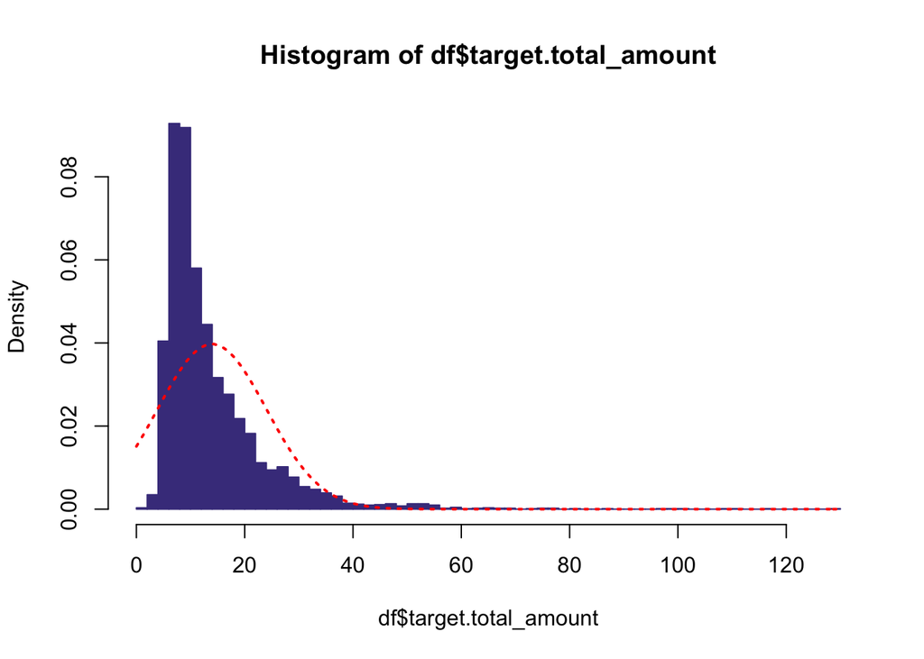

```r
hist(df$target.total_amount,50,freq=F,col="darkslateblue",border = "darkslateblue")
mm<-mean(df$target.total_amount);ss<-sd(df$target.total_amount)
curve(dnorm(x,mean=mm,sd=ss),col="red",lwd=2,lty=3, add=T)
```

```r
shapiro.test(df$target.total_amount)
```

```
##
##  Shapiro-Wilk normality test
##
## data:  df$target.total_amount
## W = 0.73071, p-value < 2.2e-16
```

We see that the target total_amount is not normally distributed for the following reasons:

### Symmetry

```r
skewness(df$target.total_amount)
```

```
## [1] 3.176789
```

Normal data should have 0 skewness: we see that our data is right skewed (3.18).

### Kurtosis

```r
kurtosis(df$target.total_amount)
```

```
## [1] 21.09556
```

Normal data should be 3. We have 21.1, so, in this case, our data is not normal.

## Method 1: take the most correlated variables

```r
# we use spearman method since out target is not normally distributed
round(cor(df[,c("target.total_amount",vars_cexp)], method="spearman"),dig=2)
```

```
##                     target.total_amount q.passenger_count q.trip_distance
## target.total_amount                1.00              0.01            0.93
## q.passenger_count                  0.01              1.00            0.01
## q.trip_distance                    0.93              0.01            1.00
## q.fare_amount                      0.97              0.01            0.95
## q.extra                            0.03              0.05           -0.05
## q.tip_amount                       0.41             -0.01            0.26
## q.tolls_amount                     0.15              0.01            0.14
## q.hour                            -0.01              0.01           -0.05
## q.tlenkm                           0.91              0.00            0.98
## q.traveltime                       0.90             -0.01            0.87
## q.espeed                           0.29              0.02            0.46
##                     q.fare_amount q.extra q.tip_amount q.tolls_amount q.hour
## target.total_amount          0.97    0.03         0.41           0.15  -0.01
## q.passenger_count            0.01    0.05        -0.01           0.01   0.01
## q.trip_distance              0.95   -0.05         0.26           0.14  -0.05
## q.fare_amount                1.00   -0.06         0.25           0.14  -0.04
## q.extra                     -0.06    1.00         0.02          -0.02   0.32
## q.tip_amount                 0.25    0.02         1.00           0.11   0.02
## q.tolls_amount               0.14   -0.02         0.11           1.00  -0.01
## q.hour                      -0.04    0.32         0.02          -0.01   1.00
## q.tlenkm                     0.94   -0.03         0.25           0.14  -0.04
## q.traveltime                 0.93   -0.03         0.22           0.11  -0.02
## q.espeed                     0.28   -0.01         0.14           0.12  -0.07
##                     q.tlenkm q.traveltime q.espeed
## target.total_amount     0.91         0.90     0.29
## q.passenger_count       0.00        -0.01     0.02
## q.trip_distance         0.98         0.87     0.46
## q.fare_amount           0.94         0.93     0.28
## q.extra                -0.03        -0.03    -0.01
## q.tip_amount            0.25         0.22     0.14
## q.tolls_amount          0.14         0.11     0.12
## q.hour                 -0.04        -0.02    -0.07
## q.tlenkm                1.00         0.88     0.45
## q.traveltime            0.88         1.00     0.05
## q.espeed                0.45         0.05     1.00
```

We see that the diagonal is full of ‘1’, since this command gives us the correlation between the same variable. Apart from this diagonal, however, there are more high correlations. Let’s see which ones are correlated with our target:

- q.fare_amount: 0.97
- q.trip_distance: 0.93
- q.tlenkm: 0.91 (like trip_distance)
- q.traveltime: 0.90
- q.tip_amount: 0.41 (not much, but must be taken into account)
- q.espeed: 0.29 (not much, but must be taken into account)
- q.tolls_amount: 0.15 (not much, but must be taken into account)
- we can see that some of them are not correlated:
  - q.extra (0.03)
  - q.passenger_count (0.01)
  - q.hour (-0.01)

After seeing the correlation, to make an initial model, we should select the ones that are most correlated, which are:

- q.fare_amount
- q.trip_distance (we are not taking tlenkm because of redundance)
- q.traveltime
- q.tip_amount
- q.espeed
- q.tolls_amount

## Method 2: take the entire dataset with a condes

```r
res.con <- condes(df,num.var=which(names(df)=="target.total_amount"))
```

```r
res.con$quanti
```

```
##                     correlation       p.value
## q.fare_amount        0.94425003  0.000000e+00
## q.trip_distance      0.89702734  0.000000e+00
## q.tlenkm             0.88671294  0.000000e+00
## q.traveltime         0.76448863  0.000000e+00
## q.tip_amount         0.56622837  0.000000e+00
## q.espeed             0.39683909 9.313540e-174
## q.tolls_amount       0.25751662  9.659999e-71
## q.hour              -0.03110910  3.465376e-02
## q.pickup_longitude  -0.04064371  5.775239e-03
## q.dropoff_longitude -0.06391905  1.401371e-05
## q.pickup_latitude   -0.12322848  4.560732e-17
## q.dropoff_latitude  -0.14812217  4.926074e-24
```

Com hem pogut veure abans, les variables més correlacionades són:

- q.fare_amount: 0.94
  - it is normal for the rate to go up when the price goes up
- q.trip_distance: 0.90
  - the more distance, the more time, and therefore the more price
- q.tlenkm: 0.88
  - just like the previous one
- q.traveltime: 0.76
  - the longer, the more price
- q.tip_amount: 0.57
  - not so much related, but we can keep in mind that people tend to give a percentage of the total price
- q.espeed: 0.40
- q.tolls_amount: 0.26

```r
res.con$quali
```

```
##                                  R2      p.value
## f.trip_distance_range   0.567177647 0.000000e+00
## f.cost                  0.908376615 0.000000e+00
## f.tt                    0.539010171 0.000000e+00
## f.dist                  0.636791987 0.000000e+00
## f.paid_tolls            0.079593357 4.072991e-85
## target.tip_is_given     0.057803014 1.250800e-61
## f.payment_type          0.052910669 4.024719e-55
## f.code_rate_id          0.018930689 6.290954e-21
## f.mta_tax               0.005160632 1.044478e-06
## f.trip_type             0.003203349 1.204051e-04
## f.improvement_surcharge 0.002760154 3.583467e-04
## qual.dropoff            0.008369578 2.171667e-02
```

To talk about factor variables, we need to visualize res.con$quali. So let’s see:

- f.trip_distance_range
  - we see that they are totally related, just as we see with que.trip_distance, since the longer distance, the longer time, and therefore the more price
- f.cost
  - is equivalent to our target
- f.tt
  - he longer time, the more price
- f.dist
  - just like with f.trip_distance_range
- f.paid_tolls
  - if you pay more, it means that the trip has lasted longer, and therefore has been longer, and is more likely to have gone through more tolls
- target.tip_is_given
  - just like before, but we can keep in mind that people tend to give a percentage of the total price

## Method 3: if few explanatory variables are available -> take all of them

```r
vars_cexp
```

```
##  [1] "q.passenger_count" "q.trip_distance"   "q.fare_amount"
##  [4] "q.extra"           "q.tip_amount"      "q.tolls_amount"
##  [7] "q.hour"            "q.tlenkm"          "q.traveltime"
## [10] "q.espeed"
```

```r
cor(df$q.trip_distance,df$q.tlenkm)
```

```
## [1] 0.9951289
```

To give an example, we see that the two distances we have, trip_distance and tlenkm, are closely related, since they represent the same.

### Model 1

```r
model_1 <- lm(
  target.total_amount~.,
  data=df[,c("target.total_amount",vars_cexp)]
)
summary(model_1)
```

```
##
## Call:
## lm(formula = target.total_amount ~ ., data = df[, c("target.total_amount",
##     vars_cexp)])
##
## Residuals:
##    Min     1Q Median     3Q    Max
## -8.562 -0.198 -0.055  0.071 94.934
##
## Coefficients:
##                    Estimate Std. Error t value Pr(>|t|)
## (Intercept)        2.153602   0.189353  11.373  < 2e-16 ***
## q.passenger_count  0.008078   0.036749   0.220 0.826033
## q.trip_distance    0.241864   0.160027   1.511 0.130756
## q.fare_amount      0.907127   0.014705  61.687  < 2e-16 ***
## q.extra            1.072076   0.107278   9.993  < 2e-16 ***
## q.tip_amount       1.045374   0.023134  45.189  < 2e-16 ***
## q.tolls_amount     1.032744   0.077728  13.287  < 2e-16 ***
## q.hour            -0.000386   0.005808  -0.066 0.947009
## q.tlenkm           0.303267   0.091687   3.308 0.000948 ***
## q.traveltime      -0.062887   0.008534  -7.369 2.02e-13 ***
## q.espeed          -0.070566   0.007275  -9.700  < 2e-16 ***
## ---
## Signif. codes:  0 '***' 0.001 '**' 0.01 '*' 0.05 '.' 0.1 ' ' 1
##
## Residual standard error: 2.581 on 4600 degrees of freedom
## Multiple R-squared:  0.934,  Adjusted R-squared:  0.9338
## F-statistic:  6506 on 10 and 4600 DF,  p-value: < 2.2e-16
```

We cannot use variables that are so correlated at the same time to act as explanatory variables. Therefore, we need to make a model in which we do not have these correlations.

But first, let’s see which of them are that correlated:

```r
vif(model_1)  # Check association between explanatory vars
```

```
## q.passenger_count   q.trip_distance     q.fare_amount           q.extra
##          1.004241        137.215426         10.203484          1.071071
##      q.tip_amount    q.tolls_amount            q.hour          q.tlenkm
##          1.247479          1.069987          1.073015        116.473412
##      q.traveltime          q.espeed
##          5.069225          2.779880
```

When the variance inflation factor is greater than 5, we need to consider whether or not we keep a variable.

- q.trip_distance: 137.215426
- q.tlenkm: 116.473412
- q.fare_amount: 10.203484
- q.traveltime: 5.069225

In this case we have to choose how far we stay. Since we work better with km than with miles (or inches, or whatever it is), we could choose the variable q.tlenkm.

### Model 1 with BIC

```r
model_1_bic <- step( model_1, k=log(nrow(df)) )
```

```
## Start:  AIC=8826.82
## target.total_amount ~ q.passenger_count + q.trip_distance + q.fare_amount +
##     q.extra + q.tip_amount + q.tolls_amount + q.hour + q.tlenkm +
##     q.traveltime + q.espeed
##
##                     Df Sum of Sq   RSS     AIC
## - q.hour             1       0.0 30650  8818.4
## - q.passenger_count  1       0.3 30650  8818.4
## - q.trip_distance    1      15.2 30665  8820.7
## <none>                           30649  8826.8
## - q.tlenkm           1      72.9 30722  8829.3
## - q.traveltime       1     361.8 31011  8872.5
## - q.espeed           1     626.9 31276  8911.8
## - q.extra            1     665.4 31315  8917.4
## - q.tolls_amount     1    1176.2 31826  8992.0
## - q.tip_amount       1   13605.8 44255 10512.3
## - q.fare_amount      1   25354.6 56004 11597.9
##
## Step:  AIC=8818.39
## target.total_amount ~ q.passenger_count + q.trip_distance + q.fare_amount +
##     q.extra + q.tip_amount + q.tolls_amount + q.tlenkm + q.traveltime +
##     q.espeed
##
##                     Df Sum of Sq   RSS     AIC
## - q.passenger_count  1       0.3 30650  8810.0
## - q.trip_distance    1      15.3 30665  8812.2
## <none>                           30650  8818.4
## - q.tlenkm           1      72.9 30722  8820.9
## - q.traveltime       1     362.0 31012  8864.1
## - q.espeed           1     629.8 31279  8903.7
## - q.extra            1     702.0 31351  8914.4
## - q.tolls_amount     1    1176.2 31826  8983.6
## - q.tip_amount       1   13611.9 44261 10504.5
## - q.fare_amount      1   25371.8 56021 11590.9
##
## Step:  AIC=8810
## target.total_amount ~ q.trip_distance + q.fare_amount + q.extra +
##     q.tip_amount + q.tolls_amount + q.tlenkm + q.traveltime +
##     q.espeed
##
```

[output cut: 9 more lines]

```
## - q.fare_amount    1   25372.8 56023 11582.6
##
## Step:  AIC=8803.85
## target.total_amount ~ q.fare_amount + q.extra + q.tip_amount +
##     q.tolls_amount + q.tlenkm + q.traveltime + q.espeed
##
##                  Df Sum of Sq   RSS     AIC
## <none>                        30665  8803.9
## - q.traveltime    1       387 31052  8853.2
## - q.espeed        1       615 31280  8886.9
## - q.extra         1       700 31365  8899.5
## - q.tolls_amount  1      1165 31830  8967.4
## - q.tlenkm        1      1873 32538  9068.8
## - q.tip_amount    1     13724 44389 10500.9
## - q.fare_amount   1     33519 64184 12201.2
```

The BIC has been eliminating the variables it has considered, without worsening the AIC. However, since it does not take into account either correlations or concepts, it is probably not optimal.

Let’s see how it turned out:

```r
vif(model_1_bic)
```

```
##  q.fare_amount        q.extra   q.tip_amount q.tolls_amount       q.tlenkm
##       7.898396       1.008633       1.241575       1.065918       9.377307
##   q.traveltime       q.espeed
##       4.984224       2.717538
```

Note that tlenkm still has a vif greater than 5 (9.377307), and so does fare_amount (7.898396).

```r
summary(model_1_bic)
```

```
##
## Call:
## lm(formula = target.total_amount ~ q.fare_amount + q.extra +
##     q.tip_amount + q.tolls_amount + q.tlenkm + q.traveltime +
##     q.espeed, data = df[, c("target.total_amount", vars_cexp)])
##
## Residuals:
##    Min     1Q Median     3Q    Max
## -8.203 -0.196 -0.053  0.070 94.855
##
## Coefficients:
##                 Estimate Std. Error t value Pr(>|t|)
## (Intercept)     2.103354   0.160998  13.064  < 2e-16 ***
## q.fare_amount   0.917656   0.012937  70.932  < 2e-16 ***
## q.extra         1.067019   0.104097  10.250  < 2e-16 ***
## q.tip_amount    1.047409   0.023077  45.387  < 2e-16 ***
## q.tolls_amount  1.025892   0.077574  13.225  < 2e-16 ***
## q.tlenkm        0.436186   0.026014  16.768  < 2e-16 ***
## q.traveltime   -0.064484   0.008461  -7.621 3.04e-14 ***
## q.espeed       -0.069090   0.007192  -9.606  < 2e-16 ***
## ---
## Signif. codes:  0 '***' 0.001 '**' 0.01 '*' 0.05 '.' 0.1 ' ' 1
##
## Residual standard error: 2.581 on 4603 degrees of freedom
## Multiple R-squared:  0.9339, Adjusted R-squared:  0.9338
## F-statistic:  9295 on 7 and 4603 DF,  p-value: < 2.2e-16
```

However, we see that it continues to explain much of the variability of our target (93.39%).

Therefore, we will try to make a model manually based on what model_1_bic has shown us and our knowledge of the data:

### Model 2

```r
model_2 <- lm(
  target.total_amount~
    q.passenger_count +
    q.fare_amount +
    q.extra +
    q.tip_amount +
    q.tolls_amount +
    q.hour +
    q.tlenkm +
    q.traveltime +
    q.espeed
  ,
  data=df[,c("target.total_amount",vars_cexp)]
)
summary(model_2)
```

```
##
## Call:
## lm(formula = target.total_amount ~ q.passenger_count + q.fare_amount +
##     q.extra + q.tip_amount + q.tolls_amount + q.hour + q.tlenkm +
##     q.traveltime + q.espeed, data = df[, c("target.total_amount",
##     vars_cexp)])
##
## Residuals:
##    Min     1Q Median     3Q    Max
## -8.205 -0.197 -0.052  0.071 94.859
##
## Coefficients:
##                     Estimate Std. Error t value Pr(>|t|)
## (Intercept)        2.1016961  0.1862386  11.285  < 2e-16 ***
## q.passenger_count  0.0074884  0.0367525   0.204    0.839
## q.fare_amount      0.9176846  0.0129422  70.907  < 2e-16 ***
## q.extra            1.0684221  0.1072657   9.961  < 2e-16 ***
## q.tip_amount       1.0475525  0.0230918  45.365  < 2e-16 ***
## q.tolls_amount     1.0257256  0.0775996  13.218  < 2e-16 ***
## q.hour            -0.0005778  0.0058073  -0.100    0.921
## q.tlenkm           0.4361459  0.0260205  16.762  < 2e-16 ***
## q.traveltime      -0.0645068  0.0084674  -7.618  3.1e-14 ***
## q.espeed          -0.0691571  0.0072157  -9.584  < 2e-16 ***
## ---
## Signif. codes:  0 '***' 0.001 '**' 0.01 '*' 0.05 '.' 0.1 ' ' 1
##
## Residual standard error: 2.582 on 4601 degrees of freedom
## Multiple R-squared:  0.9339, Adjusted R-squared:  0.9338
## F-statistic:  7226 on 9 and 4601 DF,  p-value: < 2.2e-16
```

We see that the explainability is now 93.39%.

```r
vif(model_2)  # Check association between explanatory vars
```

```
## q.passenger_count     q.fare_amount           q.extra      q.tip_amount
##          1.004128          7.901266          1.070527          1.242636
##    q.tolls_amount            q.hour          q.tlenkm      q.traveltime
##          1.066168          1.072503          9.378271          4.989265
##          q.espeed
##          2.734212
```

We try to make a new model without the distance:

### Model 3

```r
model_3 <- lm(
  target.total_amount~
    q.passenger_count +
    q.fare_amount +
    q.extra +
    q.tip_amount +
    q.tolls_amount +
    q.hour +
    q.traveltime +
    q.espeed
  ,
  data=df[,c("target.total_amount",vars_cexp)]
)
summary(model_3)
```

```
##
## Call:
## lm(formula = target.total_amount ~ q.passenger_count + q.fare_amount +
##     q.extra + q.tip_amount + q.tolls_amount + q.hour + q.traveltime +
##     q.espeed, data = df[, c("target.total_amount", vars_cexp)])
##
## Residuals:
##    Min     1Q Median     3Q    Max
## -8.322 -0.251  0.000  0.117 95.540
##
## Coefficients:
##                     Estimate Std. Error t value Pr(>|t|)
## (Intercept)        0.2903616  0.1562258   1.859   0.0631 .
## q.passenger_count  0.0132996  0.0378522   0.351   0.7253
## q.fare_amount      1.0440693  0.0108341  96.369   <2e-16 ***
## q.extra            1.1208455  0.1104332  10.150   <2e-16 ***
## q.tip_amount       1.0607708  0.0237700  44.627   <2e-16 ***
## q.tolls_amount     1.0842604  0.0798441  13.580   <2e-16 ***
## q.hour            -0.0001983  0.0059813  -0.033   0.9736
## q.traveltime      -0.0089434  0.0080250  -1.114   0.2651
## q.espeed           0.0052878  0.0058573   0.903   0.3667
## ---
## Signif. codes:  0 '***' 0.001 '**' 0.01 '*' 0.05 '.' 0.1 ' ' 1
##
## Residual standard error: 2.659 on 4602 degrees of freedom
## Multiple R-squared:  0.9299, Adjusted R-squared:  0.9298
## F-statistic:  7630 on 8 and 4602 DF,  p-value: < 2.2e-16
```

We see that the explainability is now 92.99%.

```r
vif(model_3)  # Check association between explanatory vars
```

```
## q.passenger_count     q.fare_amount           q.extra      q.tip_amount
##          1.004039          5.219389          1.069616          1.241186
##    q.tolls_amount            q.hour      q.traveltime          q.espeed
##          1.064009          1.072486          4.224578          1.698328
```

### Model 4

```r
model_4 <- lm(
  target.total_amount~
    q.passenger_count +
    q.extra +
    q.tip_amount +
    q.tolls_amount +
    q.hour +
    q.tlenkm +
    q.traveltime +
    q.espeed
  ,
  data=df[,c("target.total_amount",vars_cexp)]
)
summary(model_4)
```

```
##
## Call:
## lm(formula = target.total_amount ~ q.passenger_count + q.extra +
##     q.tip_amount + q.tolls_amount + q.hour + q.tlenkm + q.traveltime +
##     q.espeed, data = df[, c("target.total_amount", vars_cexp)])
##
## Residuals:
##     Min      1Q  Median      3Q     Max
## -44.146  -0.613  -0.248   0.192  94.727
##
## Coefficients:
##                    Estimate Std. Error t value Pr(>|t|)
## (Intercept)        4.548119   0.264727  17.180  < 2e-16 ***
## q.passenger_count  0.004933   0.053162   0.093  0.92607
## q.extra            0.552686   0.154800   3.570  0.00036 ***
## q.tip_amount       1.227130   0.033200  36.961  < 2e-16 ***
## q.tolls_amount     1.308155   0.112098  11.670  < 2e-16 ***
## q.hour             0.007250   0.008399   0.863  0.38806
## q.tlenkm           1.511058   0.030591  49.396  < 2e-16 ***
## q.traveltime       0.182147   0.011167  16.312  < 2e-16 ***
## q.espeed          -0.054416   0.010433  -5.216 1.91e-07 ***
## ---
## Signif. codes:  0 '***' 0.001 '**' 0.01 '*' 0.05 '.' 0.1 ' ' 1
##
## Residual standard error: 3.734 on 4602 degrees of freedom
## Multiple R-squared:  0.8617, Adjusted R-squared:  0.8615
## F-statistic:  3585 on 8 and 4602 DF,  p-value: < 2.2e-16
```

We see that the explainability is now 86.17%.

```r
vif(model_4)  # Check association between explanatory vars
```

```
## q.passenger_count           q.extra      q.tip_amount    q.tolls_amount
##          1.004128          1.065604          1.227688          1.063359
##            q.hour          q.tlenkm      q.traveltime          q.espeed
##          1.072115          6.195063          4.147204          2.731942
```

Despite having high vifs, we still have high explicability of the variability of our target and, given that the variable we have taken out we can remove with time and distance from the trip, we do not need it.

So we continue to stay with this variable and make new models. We apply BIC to help us a little:

```r
model_4_bic <- step( model_4, k=log(nrow(df)) )
```

```
## Start:  AIC=12217.36
## target.total_amount ~ q.passenger_count + q.extra + q.tip_amount +
##     q.tolls_amount + q.hour + q.tlenkm + q.traveltime + q.espeed
##
##                     Df Sum of Sq   RSS   AIC
## - q.passenger_count  1         0 64174 12209
## - q.hour             1        10 64184 12210
## <none>                           64174 12217
## - q.extra            1       178 64351 12222
## - q.espeed           1       379 64553 12236
## - q.tolls_amount     1      1899 66073 12343
## - q.traveltime       1      3710 67884 12468
## - q.tip_amount       1     19051 83224 13408
## - q.tlenkm           1     34025 98198 14170
##
## Step:  AIC=12208.94
## target.total_amount ~ q.extra + q.tip_amount + q.tolls_amount +
##     q.hour + q.tlenkm + q.traveltime + q.espeed
##
##                  Df Sum of Sq   RSS   AIC
## - q.hour          1        10 64184 12201
## <none>                        64174 12209
## - q.extra         1       179 64352 12213
## - q.espeed        1       379 64553 12228
## - q.tolls_amount  1      1900 66073 12335
## - q.traveltime    1      3710 67884 12460
## - q.tip_amount    1     19056 83230 13399
## - q.tlenkm        1     34030 98204 14162
##
## Step:  AIC=12201.24
## target.total_amount ~ q.extra + q.tip_amount + q.tolls_amount +
##     q.tlenkm + q.traveltime + q.espeed
##
##                  Df Sum of Sq   RSS   AIC
## <none>                        64184 12201
## - q.extra         1       211 64395 12208
## - q.espeed        1       391 64575 12221
## - q.tolls_amount  1      1902 66086 12328
## - q.traveltime    1      3703 67887 12451
## - q.tip_amount    1     19088 83272 13393
## - q.tlenkm        1     34063 98247 14156
```

Following BIC, we have to eliminate variables until the vif’s are less than 5. Therefore, the model that meets this is:

### Model 5

```r
model_5 <- lm(
  target.total_amount~
    q.passenger_count +
    q.extra +
    q.tip_amount +
    q.tolls_amount +
    q.tlenkm +
    q.traveltime
  ,
  data=df
)
summary(model_5)
```

```
##
## Call:
## lm(formula = target.total_amount ~ q.passenger_count + q.extra +
##     q.tip_amount + q.tolls_amount + q.tlenkm + q.traveltime,
##     data = df)
##
## Residuals:
##     Min      1Q  Median      3Q     Max
## -43.380  -0.644  -0.251   0.211  94.956
##
## Coefficients:
##                   Estimate Std. Error t value Pr(>|t|)
## (Intercept)       3.582803   0.125371  28.578  < 2e-16 ***
## q.passenger_count 0.001889   0.053304   0.035    0.972
## q.extra           0.605472   0.150868   4.013 6.08e-05 ***
## q.tip_amount      1.223749   0.033279  36.773  < 2e-16 ***
## q.tolls_amount    1.307289   0.112420  11.629  < 2e-16 ***
## q.tlenkm          1.385255   0.019221  72.070  < 2e-16 ***
## q.traveltime      0.221884   0.008248  26.901  < 2e-16 ***
## ---
## Signif. codes:  0 '***' 0.001 '**' 0.01 '*' 0.05 '.' 0.1 ' ' 1
##
## Residual standard error: 3.745 on 4604 degrees of freedom
## Multiple R-squared:  0.8609, Adjusted R-squared:  0.8607
## F-statistic:  4748 on 6 and 4604 DF,  p-value: < 2.2e-16
```

We see that the explainability is now 86.09%

```r
vif(model_5)  # Check association between explanatory vars
```

```
## q.passenger_count           q.extra      q.tip_amount    q.tolls_amount
##          1.003687          1.006299          1.226347          1.063286
##          q.tlenkm      q.traveltime
##          2.431645          2.249571
```

There is no vif that exceeds 5.

Let’s now discriminate the variables independently:

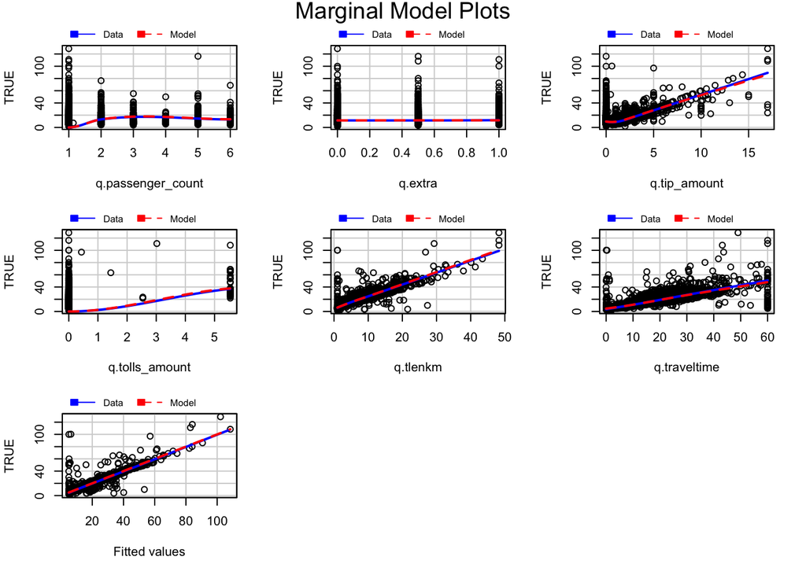

```r
marginalModelPlots(model_5)
```

We see that there is not much mismatch of the marginal variables. If there were any, we would have to transform our explanatory variables.

## Diagnostics

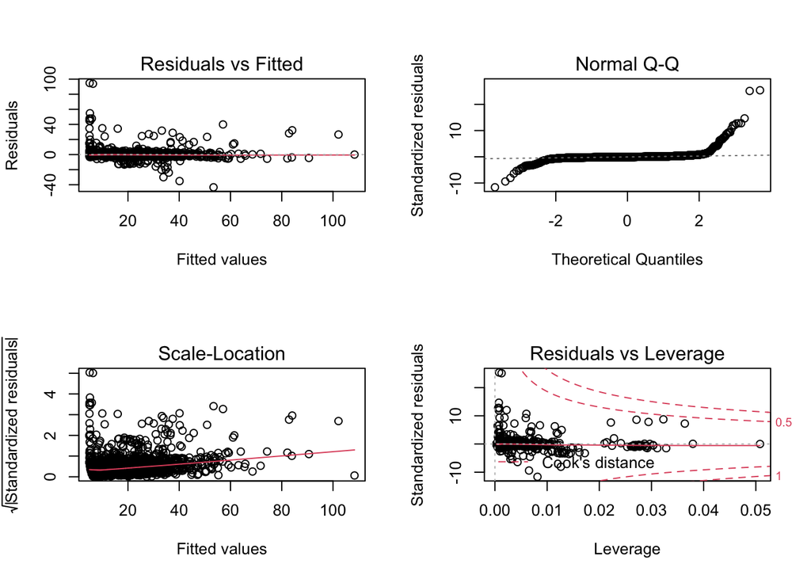

```r
par(mfrow=c(2,2))
plot(model_5, id.n=0 )
```

```r
par(mfrow=c(1,1))
```

Looking at the results, we can say that:

- There is no normality
- And, in terms of the Residual vs Leverage graph, our variables are within the R model, but it’s not very reliable, so it doesn’t help us much.

All this is due to the fact that our target variable was no longer normally distributed. To solve this, we apply the logarithm:

```r
model_6 <- lm(
  log(target.total_amount)~
    q.passenger_count +
    q.extra +
    q.tip_amount +
    q.tolls_amount +
    q.tlenkm +
    q.traveltime
  ,
  data=df
)
summary(model_6)
```

```
##
## Call:
## lm(formula = log(target.total_amount) ~ q.passenger_count + q.extra +
##     q.tip_amount + q.tolls_amount + q.tlenkm + q.traveltime,
##     data = df)
##
## Residuals:
##      Min       1Q   Median       3Q      Max
## -2.49383 -0.10927  0.03793  0.14491  2.68692
##
## Coefficients:
##                     Estimate Std. Error t value Pr(>|t|)
## (Intercept)        1.8572872  0.0084592 219.558  < 2e-16 ***
## q.passenger_count -0.0014091  0.0035967  -0.392    0.695
## q.extra            0.0704555  0.0101797   6.921 5.09e-12 ***
## q.tip_amount       0.0624228  0.0022454  27.800  < 2e-16 ***
## q.tolls_amount     0.0308942  0.0075854   4.073 4.72e-05 ***
## q.tlenkm           0.0550138  0.0012969  42.419  < 2e-16 ***
## q.traveltime       0.0220808  0.0005565  39.676  < 2e-16 ***
## ---
## Signif. codes:  0 '***' 0.001 '**' 0.01 '*' 0.05 '.' 0.1 ' ' 1
##
## Residual standard error: 0.2527 on 4604 degrees of freedom
## Multiple R-squared:  0.7951, Adjusted R-squared:  0.7948
## F-statistic:  2978 on 6 and 4604 DF,  p-value: < 2.2e-16
```

We see that when doing the logarithm, the coefficient of determination is getting lower and lower, now it is 79.51%. We have seen that it has gotten worse than the previous model. Therefore, we discard it. We will work with model_5.

However, let’s remember the last three models we used:

- Model 4
  - Coefficient of determination = 86,17%
  - VIFs:
    - q.passenger_count: 1.004128
    - q.extra: 1.065604
    - q.tip_amount: 1.227688
    - q.tolls_amount: 1.063359
    - q.hour: 1.072115
    - q.tlenkm: 6.195063
    - q.traveltime: 4.147204
    - q.espeed: 2.731942
- Model 5
  - Coefficient of determination = 86.09%
  - VIFs:
    - q.passenger_count: 1.003687
    - q.extra: 1.006299
    - q.tip_amount: 1.226347
    - q.tolls_amount: 1.063286
    - q.tlenkm: 2.431645
    - q.traveltime: .249571
- Model 6
  - Coefficient of determination = 79.51%
  - VIFs:
    - q.passenger_count: 1.003687
    - q.extra: 1.006299
    - q.tip_amount: 1.226347
    - q.tolls_amount: 1.063286
    - q.tlenkm: 2.431645
    - q.traveltime: 2.249571

According to the coefficient of explicability, the ranking is: model_4 >> model_5 >> model_6. As for the VIFs, however, the ranking is: model_6 >> model_5 >> model_4. Since VIFs are acceptable on both model_5 and model_6, and not acceptable on model_4, the smartest option is to choose model_5.

So, let’s look at the effects of this model:

```r
Anova(model_5)
```

```
## Anova Table (Type II tests)
##
## Response: target.total_amount
##                   Sum Sq   Df   F value    Pr(>F)
## q.passenger_count      0    1    0.0013    0.9717
## q.extra              226    1   16.1062 6.084e-05 ***
## q.tip_amount       18966    1 1352.2380 < 2.2e-16 ***
## q.tolls_amount      1897    1  135.2241 < 2.2e-16 ***
## q.tlenkm           72851    1 5194.0555 < 2.2e-16 ***
## q.traveltime       10150    1  723.6844 < 2.2e-16 ***
## Residuals          64575 4604
## ---
## Signif. codes:  0 '***' 0.001 '**' 0.01 '*' 0.05 '.' 0.1 ' ' 1
```

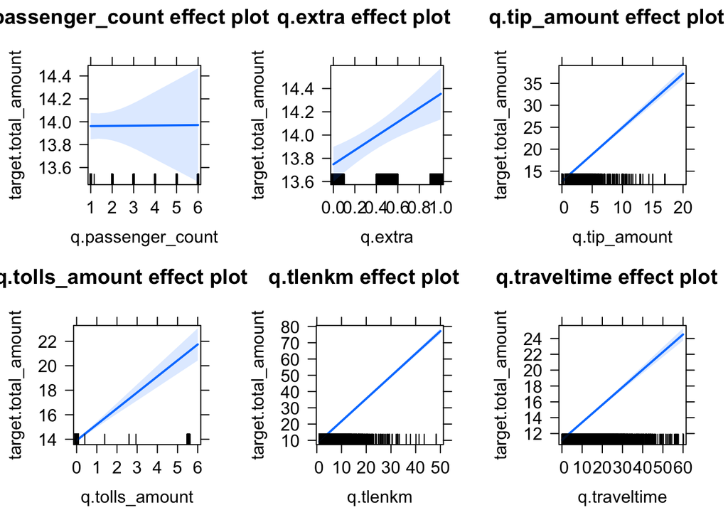

```r
library(effects)
plot(allEffects(model_5))
```

We see that our model defines the following:

- q.passenger_count does not depend on target.total_amount
- q.extra grows if target.total_amount grows
- q.tip_amount grows if target.total_amount grows
- q.tolls_amount grows if target.total_amount grows
- q.tlenkm grows if target.total_amount grows
- q.traveltime grows if target.total_amount grows

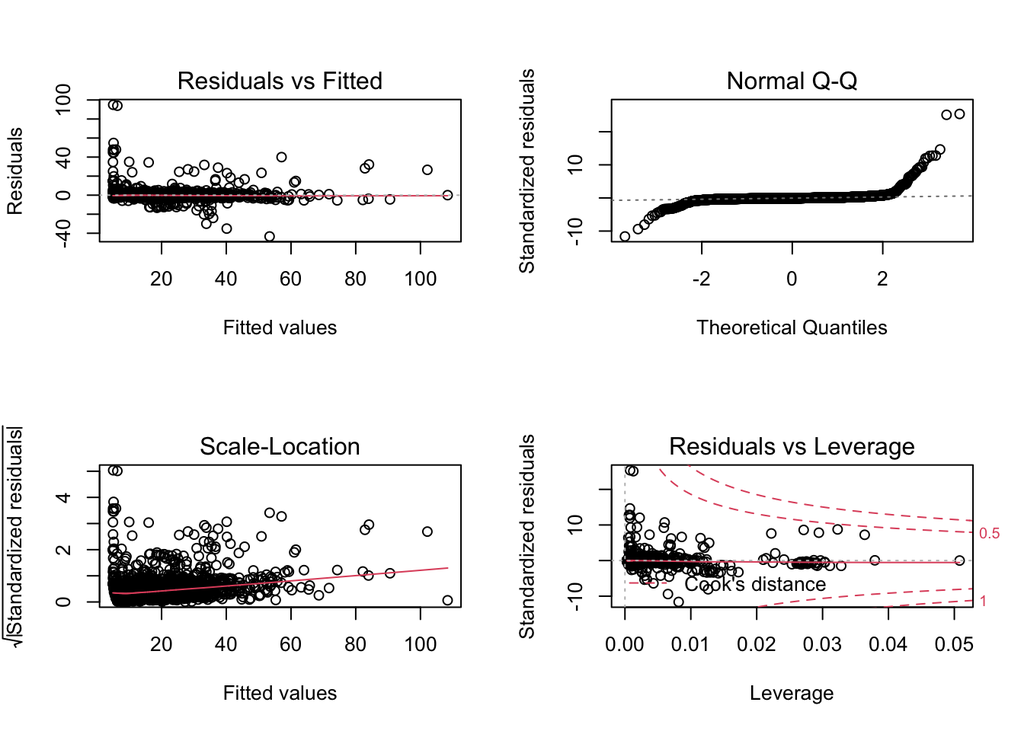

```r
par(mfrow=c(2,2))
plot(model_5, id.n=0 )
```

```r
par(mfrow=c(1,1))
```

We see that the residues are not completely optimal.

```r
library(MASS)
boxcox(
    target.total_amount~
    q.passenger_count +
    q.extra +
    q.tip_amount +
    q.tolls_amount +
    q.tlenkm +
    q.traveltime
  ,
  data=df
)
```

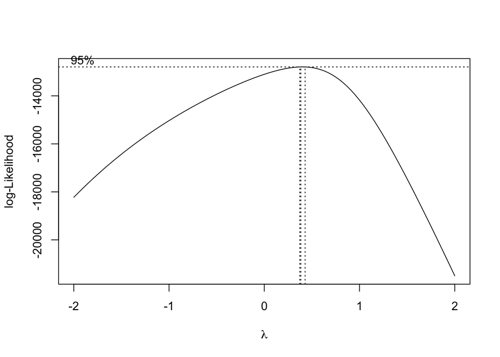

We see the lambda parameter estimation method in the boxcox method. This gives us an idea of the power to which we need to raise the target variable in order to improve the properties of the linear model.

It is worth trying a new model with a square root in the target variable:

```r
model_7 <- lm(
  sqrt(target.total_amount)~
    q.passenger_count +
    q.extra +
    q.tip_amount +
    q.tolls_amount +
    q.tlenkm +
    q.traveltime
  ,
  data=df
)
summary(model_7)
```

```
##
## Call:
## lm(formula = sqrt(target.total_amount) ~ q.passenger_count +
##     q.extra + q.tip_amount + q.tolls_amount + q.tlenkm + q.traveltime,
##     data = df)
##
## Residuals:
##     Min      1Q  Median      3Q     Max
## -4.7437 -0.1380  0.0139  0.1508  7.4872
##
## Coefficients:
##                     Estimate Std. Error t value Pr(>|t|)
## (Intercept)        2.3699317  0.0136357 173.804  < 2e-16 ***
## q.passenger_count -0.0013314  0.0057976  -0.230    0.818
## q.extra            0.0977427  0.0164089   5.957 2.77e-09 ***
## q.tip_amount       0.1318869  0.0036195  36.438  < 2e-16 ***
## q.tolls_amount     0.1030452  0.0122272   8.428  < 2e-16 ***
## q.tlenkm           0.1322517  0.0020905  63.262  < 2e-16 ***
## q.traveltime       0.0357927  0.0008971  39.899  < 2e-16 ***
## ---
## Signif. codes:  0 '***' 0.001 '**' 0.01 '*' 0.05 '.' 0.1 ' ' 1
##
## Residual standard error: 0.4073 on 4604 degrees of freedom
## Multiple R-squared:  0.8641, Adjusted R-squared:  0.8639
## F-statistic:  4879 on 6 and 4604 DF,  p-value: < 2.2e-16
```

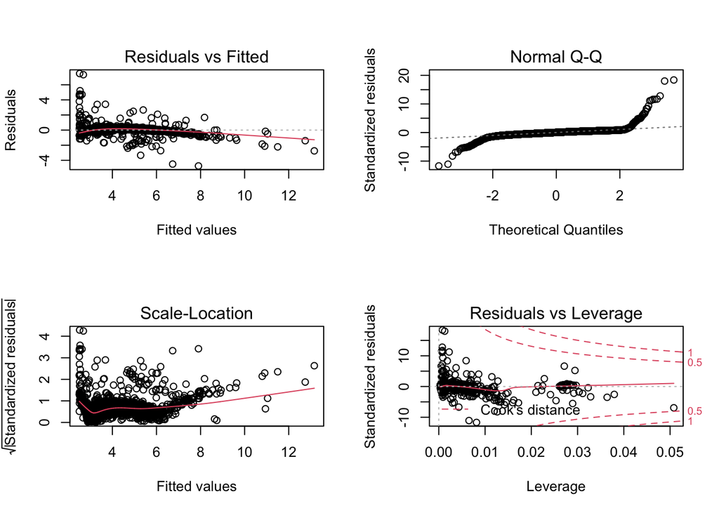

```r
par(mfrow=c(2,2))
plot( model_7, id.n=0 )
```

```r
par(mfrow=c(1,1))
```

We see we haven’t won too much. So we stick to model_5.

## Using factors as explanatory variables

### Try to change numerical each regressor by its discretized factor

```r
model_8<-lm(log(target.total_amount)~ q.extra + q.tip_amount +  q.tolls_amount + f.improvement_surcharge + q.espeed  + log(q.tlenkm), data=df)
summary(model_8)
```

```
##
## Call:
## lm(formula = log(target.total_amount) ~ q.extra + q.tip_amount +
##     q.tolls_amount + f.improvement_surcharge + q.espeed + log(q.tlenkm),
##     data = df)
##
## Residuals:
##      Min       1Q   Median       3Q      Max
## -2.14903 -0.06792 -0.01991  0.05069  2.77861
##
## Coefficients:
##                              Estimate Std. Error t value Pr(>|t|)
## (Intercept)                 2.0982020  0.0205582 102.061  < 2e-16 ***
## q.extra                     0.0884882  0.0079393  11.146  < 2e-16 ***
## q.tip_amount                0.0655898  0.0017109  38.337  < 2e-16 ***
## q.tolls_amount              0.0428318  0.0058348   7.341  2.5e-13 ***
## f.improvement_surchargeYes -0.2523217  0.0194490 -12.974  < 2e-16 ***
## q.espeed                   -0.0091816  0.0003899 -23.550  < 2e-16 ***
## log(q.tlenkm)               0.6191131  0.0044464 139.239  < 2e-16 ***
## ---
## Signif. codes:  0 '***' 0.001 '**' 0.01 '*' 0.05 '.' 0.1 ' ' 1
##
## Residual standard error: 0.1953 on 4604 degrees of freedom
## Multiple R-squared:  0.8777, Adjusted R-squared:  0.8775
## F-statistic:  5505 on 6 and 4604 DF,  p-value: < 2.2e-16
```

We see that the explainability is now 87.77%. The more influent effects in this models are the length in km of the trip and the tip amount given.

```r
Anova(model_8)
```

```
## Anova Table (Type II tests)
##
## Response: log(target.total_amount)
##                         Sum Sq   Df   F value    Pr(>F)
## q.extra                   4.74    1   124.225 < 2.2e-16 ***
## q.tip_amount             56.03    1  1469.717 < 2.2e-16 ***
## q.tolls_amount            2.05    1    53.886 2.499e-13 ***
## f.improvement_surcharge   6.42    1   168.312 < 2.2e-16 ***
## q.espeed                 21.14    1   554.595 < 2.2e-16 ***
## log(q.tlenkm)           739.16    1 19387.533 < 2.2e-16 ***
## Residuals               175.53 4604
## ---
## Signif. codes:  0 '***' 0.001 '**' 0.01 '*' 0.05 '.' 0.1 ' ' 1
```

```r
vif(model_8)
```

```
##                 q.extra            q.tip_amount          q.tolls_amount
##                1.025199                1.192442                1.053741
## f.improvement_surcharge                q.espeed           log(q.tlenkm)
##                1.027504                1.395417                1.545375
```

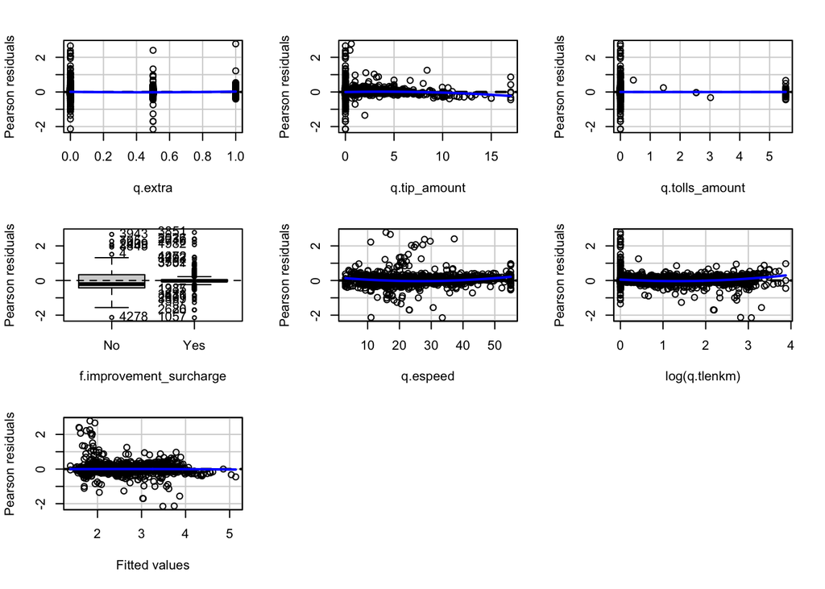

```
##                         Test stat Pr(>|Test stat|)
## q.extra                    5.5432        3.135e-08 ***
## q.tip_amount              -4.5251        6.189e-06 ***
## q.tolls_amount             0.0307           0.9755
## f.improvement_surcharge
## q.espeed                  13.5154        < 2.2e-16 ***
## log(q.tlenkm)             13.8598        < 2.2e-16 ***
## Tukey test                -0.6750           0.4997
## ---
## Signif. codes:  0 '***' 0.001 '**' 0.01 '*' 0.05 '.' 0.1 ' ' 1
```

```r
residualPlots(model_8)
```

```r
# vars_enum<-c("q.extra","q.tip_amount","q.tolls_amount","f.improvement_surcharge","tlenkm")
# vars_edis<-c("VendorID","RateCodeID","Payment_type","period")
#
df$f.extra <- factor(df$q.extra)

model_9<-lm(
  log(target.total_amount)~
    f.extra +
    q.tip_amount +
    q.tolls_amount +
    f.improvement_surcharge +
    q.espeed +
    log(q.tlenkm)
  ,data=df
)
BIC(model_8,model_9)
```

```
##         df       BIC
## model_8  8 -1917.617
## model_9  9 -1939.860
```

We can see from the BIC that the model_9 is better than the model_8, so it is correct to consider extra as factor. Next, we will do the same with the tolls_amount and use the factor we had already created (paid_tolls).

```r
model_10<-lm(
  log(target.total_amount)~
    f.extra +
    q.tip_amount +
    f.paid_tolls +
    f.improvement_surcharge +
    q.espeed +
    log(q.tlenkm)
  ,data=df
)
BIC(model_8,model_9,model_10)
```

```
##          df       BIC
## model_8   8 -1917.617
## model_9   9 -1939.860
## model_10  9 -1944.606
```

We see can see that it is correct to use the paid_tolls factor to improve our model. We will try it now with the effective speed.

```r
df$f.espeed <- factor(df$q.espeed)
model_11<-lm(
  log(target.total_amount)~
    f.extra +
    q.tip_amount +
    f.paid_tolls +
    f.improvement_surcharge +
    f.espeed +
    log(q.tlenkm)
  ,data=df
)
BIC(model_8,model_9,model_10,model_11)
```

```
##            df       BIC
## model_8     8 -1917.617
## model_9     9 -1939.860
## model_10    9 -1944.606
## model_11 4164 18739.406
```

We can see that the best approach is the model_10, so we are going to stick to it for now.

```r
model_12 <- model_10

Anova(model_12)
```

```
## Anova Table (Type II tests)
##
## Response: log(target.total_amount)
##                         Sum Sq   Df   F value    Pr(>F)
## f.extra                   5.89    2    77.880 < 2.2e-16 ***
## q.tip_amount             55.28    1  1460.732 < 2.2e-16 ***
## f.paid_tolls              2.12    1    55.915 9.007e-14 ***
## f.improvement_surcharge   5.88    1   155.314 < 2.2e-16 ***
## q.espeed                 18.07    1   477.567 < 2.2e-16 ***
## log(q.tlenkm)           730.06    1 19292.288 < 2.2e-16 ***
## Residuals               174.19 4603
## ---
## Signif. codes:  0 '***' 0.001 '**' 0.01 '*' 0.05 '.' 0.1 ' ' 1
```

```r
summary(model_12)
```

```
##
## Call:
## lm(formula = log(target.total_amount) ~ f.extra + q.tip_amount +
##     f.paid_tolls + f.improvement_surcharge + q.espeed + log(q.tlenkm),
##     data = df)
##
## Residuals:
##      Min       1Q   Median       3Q      Max
## -2.13181 -0.06786 -0.01713  0.04833  2.75572
##
## Coefficients:
##                              Estimate Std. Error t value Pr(>|t|)
## (Intercept)                 2.0895877  0.0205470 101.698  < 2e-16 ***
## f.extra0.5                  0.0158044  0.0064600   2.446   0.0145 *
## f.extra1                    0.1027775  0.0083225  12.349  < 2e-16 ***
## q.tip_amount                0.0653075  0.0017087  38.220  < 2e-16 ***
## f.paid_tollsYes             0.2296901  0.0307168   7.478 9.01e-14 ***
## f.improvement_surchargeYes -0.2424837  0.0194571 -12.462  < 2e-16 ***
## q.espeed                   -0.0087026  0.0003982 -21.853  < 2e-16 ***
## log(q.tlenkm)               0.6171457  0.0044432 138.897  < 2e-16 ***
## ---
## Signif. codes:  0 '***' 0.001 '**' 0.01 '*' 0.05 '.' 0.1 ' ' 1
##
## Residual standard error: 0.1945 on 4603 degrees of freedom
## Multiple R-squared:  0.8786, Adjusted R-squared:  0.8784
## F-statistic:  4759 on 7 and 4603 DF,  p-value: < 2.2e-16
```

We can see from the Anova test that f.extra has 2 freedom degrees and globally it does have a significant net effect once the other variables are in the model.

We are going to take a look at the residues.

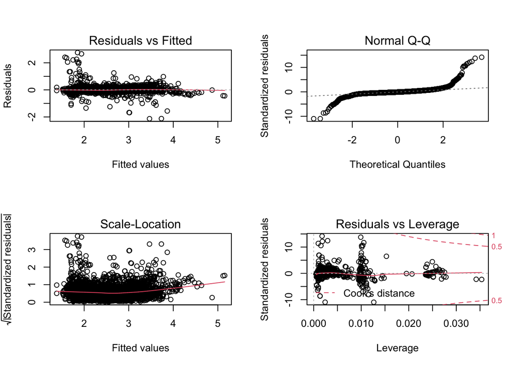

```r
par(mfrow=c(2,2))
plot( model_12, id.n=0 )
```

```r
par(mfrow=c(1,1))
```

Looking at the results, we can say that:

- There is no normality
- And, in terms of the Residual vs Leverage graph, our variables are within the R model, but it’s not very reliable, so it doesn’t help us much.

We proceed to take a look at the influence plot to check our influent residuals for model_12.

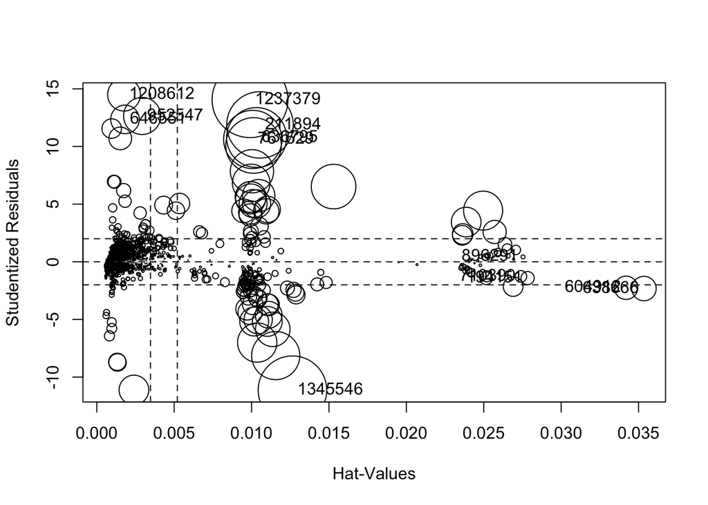

```
##             StudRes         Hat        CookD
## 194151   -1.4165961 0.027830775 0.0071794393
## 211894   11.8720921 0.010543346 0.1821960413
## 604912   -2.2551896 0.034191469 0.0224862744
## 636795   10.7789754 0.010322738 0.1477856180
## 638666   -2.3209123 0.035346786 0.0246486143
## 646551   12.3519800 0.001824547 0.0337490049
## 710390   -1.2640287 0.027396540 0.0056250635
## 761529   10.6109774 0.010077102 0.1398787908
## 896291    0.4256356 0.027534736 0.0006413128
## 952547   12.6484050 0.002931994 0.0568424885
## 1208612  14.4971050 0.001762369 0.0443645191
## 1237379  14.0568677 0.009901130 0.2368806919
## 1345546 -11.1335622 0.012642289 0.1932327624
```

```r
influencePlot( model_12, id=c(list="noteworthy",n=5))
```

Per tal de que no ens passi això, hem de treballar la variable q.tlenkm.

Anem doncs a crear un model nou que no doni tants problemes:

```r
model_13<-lm(
  log(target.total_amount)~
    f.extra +
    q.tip_amount +
    f.paid_tolls +
    f.improvement_surcharge +
    q.espeed +
    q.tlenkm
  ,data=df
)

BIC(model_12,model_13)
```

```
##          df       BIC
## model_12  9 -1944.606
## model_13  9  1610.322
```

```r
summary(model_13)
```

```
##
## Call:
## lm(formula = log(target.total_amount) ~ f.extra + q.tip_amount +
##     f.paid_tolls + f.improvement_surcharge + q.espeed + q.tlenkm,
##     data = df)
##
## Residuals:
##     Min      1Q  Median      3Q     Max
## -3.0309 -0.1465  0.0313  0.1777  2.4062
##
## Coefficients:
##                              Estimate Std. Error t value Pr(>|t|)
## (Intercept)                 2.2352725  0.0302432  73.910  < 2e-16 ***
## f.extra0.5                  0.0132780  0.0095068   1.397    0.163
## f.extra1                    0.0943882  0.0122369   7.713 1.49e-14 ***
## q.tip_amount                0.0687619  0.0025434  27.036  < 2e-16 ***
## f.paid_tollsYes             0.0695212  0.0453284   1.534    0.125
## f.improvement_surchargeYes -0.1517922  0.0286010  -5.307 1.17e-07 ***
## q.espeed                   -0.0074225  0.0006031 -12.307  < 2e-16 ***
## q.tlenkm                    0.0992084  0.0012353  80.313  < 2e-16 ***
## ---
## Signif. codes:  0 '***' 0.001 '**' 0.01 '*' 0.05 '.' 0.1 ' ' 1
##
## Residual standard error: 0.286 on 4603 degrees of freedom
## Multiple R-squared:  0.7376, Adjusted R-squared:  0.7372
## F-statistic:  1848 on 7 and 4603 DF,  p-value: < 2.2e-16
```

```r
vif(model_13)
```

```
##                             GVIF Df GVIF^(1/(2*Df))
## f.extra                 1.088146  2        1.021343
## q.tip_amount            1.228113  1        1.108202
## f.paid_tolls            1.069894  1        1.034357
## f.improvement_surcharge 1.035543  1        1.017617
## q.espeed                1.556062  1        1.247422
## q.tlenkm                1.721901  1        1.312212
```

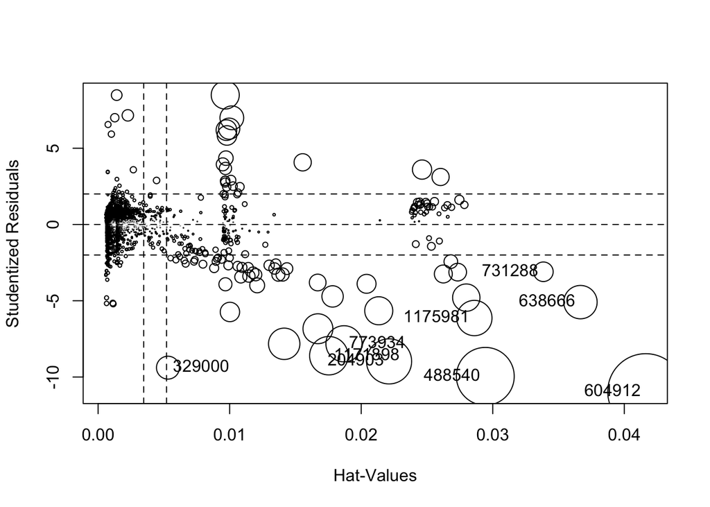

```
##            StudRes         Hat      CookD
## 204903   -8.974546 0.022119157 0.22386020
## 329000   -9.386645 0.005309257 0.05769451
## 488540   -9.956172 0.029435567 0.36794420
## 604912  -10.963556 0.041632644 0.63622612
## 638666   -5.090242 0.036668676 0.12262033
## 731288   -3.099438 0.033850655 0.04199403
## 773934   -7.821949 0.018692543 0.14380097
## 1171898  -8.602314 0.017539523 0.16255854
## 1175981  -6.133219 0.028602865 0.13735947
```

```r
influencePlot( model_13, id=c(list="noteworthy",n=5))
```

Ara doncas, anem a analitzar-lo:

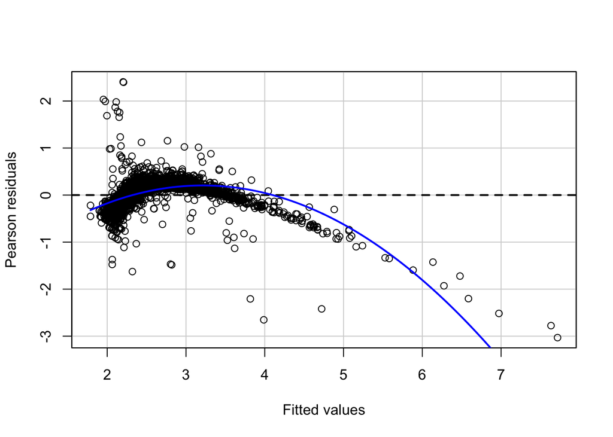

```r
residualPlot(model_13)
```

```r
# residualPlots( m35 )
# marginalModelPlots( m35 )
#
# ll1<-Boxplot(rstudent(m35));ll1
# # ll1<-which(row.names(df) %in% names(rstudent(m25)[sel1]));ll1
# df[ll1,]
# ll4 <- Boxplot( cooks.distance( m35 ));ll4
# ll4<-c(649, 4088)
# dfred<-df[-ll4,]
#
# # Outliers dels residus - Verticals - Cal suprimir-los: el model no pot explicar-los
#
# m36<-lm(log(Total_amount) ~ f.extra + Tip_amount + f.tolls+ f.scharge + f.speed + log(tlenkm)  ,data=dfred)
# summary(m36)
# Anova(m36)
# vif(m36)
```

### Adding factors: main effects

```r
# names(df)
# m40<-lm(log(Total_amount) ~ Tip_amount + log(tlenkm)+ f.tolls+ f.scharge + f.speed + f.extra + RateCodeID + VendorID + Payment_type+period ,data=df)
#
# summary(m40)
# Anova( m40 )
#
# m41<-lm(log(Total_amount) ~ Tip_amount + log(tlenkm)+ f.tolls + f.speed + f.extra + RateCodeID + Payment_type+period ,data=df)
#
# anova(m41, m40)
```

```r
# Interactions
#
# m50<-lm(log(Total_amount) ~ (Tip_amount + log(tlenkm))*(f.tolls + f.speed + f.extra + RateCodeID + Payment_type+period) ,data=df)
#
# m51<-step( m50, k=log(nrow(df)))
# Anova(m51)
# summary( m51 )
#
#
# m55<- ....
#
# ll1<-Boxplot(rstudent(m55));ll1
# sel2<-which(hatvalues(m55)>5*length(m55$coefficients)/nrow(df));sel2;length(sel2)
# ll2<-which(row.names(df) %in% names(hatvalues(m25)[sel2]));ll2
# sel3<-which(cooks.distance(m55)> 0.5 );sel3;length(sel3)
# ll3<-which(row.names(df) %in% names(cooks.distance(m55)[sel3]));ll3
```

## Multivariant Analysis conducted in previous deliverables has to be used to select the initial model. Students have some degrees in freedom in model building, but the following conditions are requested:

- At least two numerical variables have to be considered as explicative variables for initial steps in model building, called covariates. Non-linear models have to be checked for consistency.
- Select the most significant factors found in Multivariant Data Analysis as initial model factors. Put some reasonable limits to initial model complexity.
- **You have to consider at least one interaction between a couple of factors and one interaction between factor and covariate.**
- Diagnostics of the final model have to be undertaken. Lack of fit observations and influence data have to be selected and discussed (connections to multidimensional outliers in Multivariant Data Analysis is highly valuable)

## Outcome/Target : A binary response variable (Binary Target) will be the response variable for Binary Regression Models included in Statistical Modeling Part III.

- Explicative Variables for modeling purposes are those available in dataset, exceptions will be indicated, if any.
- Multivariant Analysis conducted in previous deliverables has to be used to select the initial model. Students have some degrees in freedom in model building, but the following conditions are requested:
  - Split the sample in work and test samples (consisting on a 80-20 split). Working data frame has to be used for model building purposes.
  - At least two numerical variables have to be considered as explicative variables for initial steps in model building.
  - Select the most significant factors according to feature selection as initial model factors. Put some reasonable limits to initial model complexity.
  - **You have to consider at least one interaction between a couple of factors and one interaction between factor and covariate.**
  - Diagnostics of the final model have to be undertaken. Lack of fit observations and influence data have to be selected and discussed (connections to multidimensional outliers in Multivariant Data Analysis is highly valuable).
  - You have to predict Y (Binary Target) in the Working Data Frame vs the rest according to the best validated model that you can find and make a confusion matrix.
  - Make a confusion matrix in the Testing Data Frame for **Y (Binary Target)** according to the best validated model found.

## Confusion Matrix:

When referring to the performance of a classification model, we are interested in the model’s ability to correctly predict or separate the classes. When looking at the errors made by a classification model, the confusion matrix gives the full picture. Consider e.g. a three class problem with the classes A, and B. The confusion matrix shows how the predictions are made by the model. The rows correspond to the known class of the data, i.e. the labels in the data. The columns correspond to the predictions made by the model. The value of each of element in the matrix is the number of predictions made with the class corresponding to the column for examples with the correct value as represented by the row. Thus, the diagonal elements show the number of correct classifications made for each class, and the off-diagonal elements show the errors made.